# Customer Experience Analytics for Online Food Ordering

### Context

The number of restaurants in New York is increasing day by day. Lots of students and busy professionals rely on those restaurants due to their hectic lifestyles. Online food delivery service is a great option for them. It provides them with good food from their favorite restaurants. A food aggregator company FoodHub offers access to multiple restaurants through a single smartphone app.

The app allows the restaurants to receive a direct online order from a customer. The app assigns a delivery person from the company to pick up the order after it is confirmed by the restaurant. The delivery person then uses the map to reach the restaurant and waits for the food package. Once the food package is handed over to the delivery person, he/she confirms the pick-up in the app and travels to the customer's location to deliver the food. The delivery person confirms the drop-off in the app after delivering the food package to the customer. The customer can rate the order in the app. The food aggregator earns money by collecting a fixed margin of the delivery order from the restaurants.

### Objective

The food aggregator company has stored the data of the different orders made by the registered customers in their online portal. They want to analyze the data to get a fair idea about the demand of different restaurants which will help them in enhancing their customer experience. The following questions need to be answered:

1. What is the minimum, average, and maximum time it takes for food to be prepared once an order is placed?
2. How many orders are not rated?
3. Which are the top 5 restaurants in terms of the number of orders received?
4. Which is the most popular cuisine on weekends?
5. What percentage of the orders cost more than 20 dollars?
6. What is the mean order delivery time?
7. The company has decided to give 20% discount vouchers to the top 5 most frequent customers. Find the IDs of these customers and the number of orders they placed.
8. The company wants to provide a promotional offer in the advertisement of the restaurants. The condition to get the offer is that the restaurants must have a rating count of more than 50 and the average rating should be greater than 4 Find the restaurants fulfilling the criteria to get the promotional offer.
9. The company charges the restaurant 25% on the orders having cost greater than 20 dollars and 15% on the orders having cost greater than 5 dollars. Find the net revenue generated by the company across all orders.
10. The company wants to analyze the total time required to deliver the food. What percentage of orders take more than 60 minutes to get delivered from the time the order is placed?
11. The company wants to analyze the delivery time of the orders on weekdays and weekends. How does the mean delivery time vary during weekdays and weekends?
12. What are your conclusions from the analysis? What recommendations would you like to share to help improve the business?

### Data Description

The data contains the different data related to a food order.

### Data Dictionary

- order_id: Unique ID of the order
- customer_id: ID of the customer who ordered the food
- restaurant_name: Name of the restaurant
- cuisine_type: Cuisine ordered by the customer
- cost: Cost of the order
- day_of_the_week: Indicates whether the order is placed on a weekday or weekend (The weekday is from Monday to Friday and the weekend is Saturday and Sunday)
- rating: Rating given by the customer out of 5
- food_preparation_time: Time (in minutes) taken by the restaurant to prepare the food. This is calculated by taking the difference between the timestamps of the restaurant's order confirmation and the delivery person's pick-up confirmation.
- delivery_time: Time (in minutes) taken by the delivery person to deliver the food package. This is calculated by taking the difference between the timestamps of the delivery person's pick-up confirmation and drop-off information

## Recommendations:

- Work on getting the time to prepare and deliver an order to between 35 and 40 minutes
  - 30 minutes is the national standard
  - It should take 10 to 15 minutes to prepare an order
  - It should not take over 15 minutes to deliver an order
- Start by working on the top four cusinie types getting the most orders:
  - American
  - Japanese
  - Italian
  - Chinese
- Add drivers on weekends when demand is the highest
- Consider restricting delivery area to speed the delivery time time
- Work with the restaurant partners to improve food preparation time
- Consider dropping the cuisine types with the least orders:
  - Southern 17 orders
  - Korean 13 orders
  - Spanish 12 orders
  - Vietnamese 7 orders
- Work on increasing the number of repeat customers
  - Add incentives or giving discounts on future orders

## Future considerations:

- Add weather data to the analysis to determine if/how weather is affecting delivery times
- Add time of day to the orders to detemine when the majority of orders are placed on the weekends
  - That is when drivers will be needed the most
- Add geographic data to determine what areas of the city generate the most orders
  - Preposition drivers in those areas to be ready for the orders
- Perform a deeper drive on the top four cuisine types to determine exact cost and profit for the deliveries
- Perform sentament analysis on customer rating and reviews

### Import required libraries

```python
# import libraries for data manipulation
import numpy as np
import pandas as pd

# import libraries for data visualization
import matplotlib.pyplot as plt
import seaborn as sns

# disable warnings
import warnings
warnings.filterwarnings("ignore")
```

### Review the structure of the data

```python
# uncomment and run the following lines for Google Colab
# from google.colab import drive
# drive.mount('/content/drive')
```

```python
# read the data
df = pd.read_csv('TestData_Files/foodhub_order.csv')
#Ran code on local machine using Anaconda

# returns the first 5 rows
df.head()
```

|  | order_id | customer_id | restaurant_name | cuisine_type | cost_of_the_order | day_of_the_week | rating | food_preparation_time | delivery_time |
| --- | --- | --- | --- | --- | --- | --- | --- | --- | --- |
| 0 | 1477147 | 337525 | Hangawi | Korean | 30.75 | Weekend | Not given | 25 | 20 |
| 1 | 1477685 | 358141 | Blue Ribbon Sushi Izakaya | Japanese | 12.08 | Weekend | Not given | 25 | 23 |
| 2 | 1477070 | 66393 | Cafe Habana | Mexican | 12.23 | Weekday | 5 | 23 | 28 |
| 3 | 1477334 | 106968 | Blue Ribbon Fried Chicken | American | 29.20 | Weekend | 3 | 25 | 15 |
| 4 | 1478249 | 76942 | Dirty Bird to Go | American | 11.59 | Weekday | 4 | 25 | 24 |

#### Observations:

The DataFrame has 9 columns as mentioned in the Data Dictionary. Data in each row corresponds to the order placed by a customer.

```python
print("There are", df.shape[0], 'rows and', df.shape[1], "columns.")
```

```
There are 1898 rows and 9 columns.
```

```python
# Use info() to print a concise summary of the DataFrame
df.info()
```

```
<class 'pandas.core.frame.DataFrame'>
RangeIndex: 1898 entries, 0 to 1897
Data columns (total 9 columns):
 #   Column                 Non-Null Count  Dtype
---  ------                 --------------  -----
 0   order_id               1898 non-null   int64
 1   customer_id            1898 non-null   int64
 2   restaurant_name        1898 non-null   object
 3   cuisine_type           1898 non-null   object
 4   cost_of_the_order      1898 non-null   float64
 5   day_of_the_week        1898 non-null   object
 6   rating                 1898 non-null   object
 7   food_preparation_time  1898 non-null   int64
 8   delivery_time          1898 non-null   int64
dtypes: float64(1), int64(4), object(4)
memory usage: 133.6+ KB
```

#### Observations:

```python
#Changing the columns 'cuisine type' and 'day of the week' into the category data type because that is what they are
#Suggestion from Tasleem

df['cuisine_type'] = df.cuisine_type.astype('category')
df['day_of_the_week'] = df.day_of_the_week.astype('category')
df.info()
```

```
<class 'pandas.core.frame.DataFrame'>
RangeIndex: 1898 entries, 0 to 1897
Data columns (total 9 columns):
 #   Column                 Non-Null Count  Dtype
---  ------                 --------------  -----
 0   order_id               1898 non-null   int64
 1   customer_id            1898 non-null   int64
 2   restaurant_name        1898 non-null   object
 3   cuisine_type           1898 non-null   category
 4   cost_of_the_order      1898 non-null   float64
 5   day_of_the_week        1898 non-null   category
 6   rating                 1898 non-null   object
 7   food_preparation_time  1898 non-null   int64
 8   delivery_time          1898 non-null   int64
dtypes: category(2), float64(1), int64(4), object(2)
memory usage: 108.4+ KB
```

```python
df.isnull().sum()
```

```
order_id                 0
customer_id              0
restaurant_name          0
cuisine_type             0
cost_of_the_order        0
day_of_the_week          0
rating                   0
food_preparation_time    0
delivery_time            0
dtype: int64
```

#### Observations:

No missing values. This was seen in the Question 2. There are 1898 rows and each line has 1898 non-null entries.

```python
df.isnull().sum()
```

```
order_id                 0
customer_id              0
restaurant_name          0
cuisine_type             0
cost_of_the_order        0
day_of_the_week          0
rating                   0
food_preparation_time    0
delivery_time            0
dtype: int64
```

Cross check of answer to Question 3 using another method. I also wanted to try the isnumm() method

### **Question 1:** What is the minimum, average, and maximum time it takes for food to be prepared once an order is placed?

```python
df.describe().T
```

|  | count | mean | std | min | 25% | 50% | 75% | max |
| --- | --- | --- | --- | --- | --- | --- | --- | --- |
| order_id | 1898.0 | 1.477496e+06 | 548.049724 | 1476547.00 | 1477021.25 | 1477495.50 | 1.477970e+06 | 1478444.00 |
| customer_id | 1898.0 | 1.711685e+05 | 113698.139743 | 1311.00 | 77787.75 | 128600.00 | 2.705250e+05 | 405334.00 |
| cost_of_the_order | 1898.0 | 1.649885e+01 | 7.483812 | 4.47 | 12.08 | 14.14 | 2.229750e+01 | 35.41 |
| food_preparation_time | 1898.0 | 2.737197e+01 | 4.632481 | 20.00 | 23.00 | 27.00 | 3.100000e+01 | 35.00 |
| delivery_time | 1898.0 | 2.416175e+01 | 4.972637 | 15.00 | 20.00 | 25.00 | 2.800000e+01 | 33.00 |

#### Observations:

- The minimum food preparation time is: 20 minutes
- The average or mean food preparation time is: 27.37 minutes
- The maximum food preparation time is: 35 minutes

Transposing the frame makes it easier to read.

```python
round(df['food_preparation_time'].mean(), 2)

#This result is easier to read
```

```
27.37
```

### **Question 2:** How many orders are not rated?

```python
print(df['rating'].value_counts())
print('\n Get percentage of total:')
df['rating'].value_counts(normalize=True)
```

```
Not given    736
5            588
4            386
3            188
Name: rating, dtype: int64

 Get percentage of total:
```

```
Not given    0.387777
5            0.309800
4            0.203372
3            0.099052
Name: rating, dtype: float64
```

#### Observations:

There are 736 orders that are not rated or 38.77% of the sample data set. This is rather high.

### Exploratory Data Analysis (EDA)

### Univariate Analysis

```python
print('This is the number of orders for each cuisine type:')
print(df['cuisine_type'].value_counts())
print('\n Percentage of total')
df['cuisine_type'].value_counts(normalize=True)
```

```
This is the number of orders for each cuisine type:
American          584
Japanese          470
Italian           298
Chinese           215
Mexican            77
Indian             73
Middle Eastern     49
Mediterranean      46
Thai               19
French             18
Southern           17
Korean             13
Spanish            12
Vietnamese          7
Name: cuisine_type, dtype: int64

 Percentage of total
```

```
American          0.307692
Japanese          0.247629
Italian           0.157007
Chinese           0.113277
Mexican           0.040569
Indian            0.038462
Middle Eastern    0.025817
Mediterranean     0.024236
Thai              0.010011
French            0.009484
Southern          0.008957
Korean            0.006849
Spanish           0.006322
Vietnamese        0.003688
Name: cuisine_type, dtype: float64
```

Using a bar chart to see the most popular cuisines. This shows the dominance of the top four cuisine types.

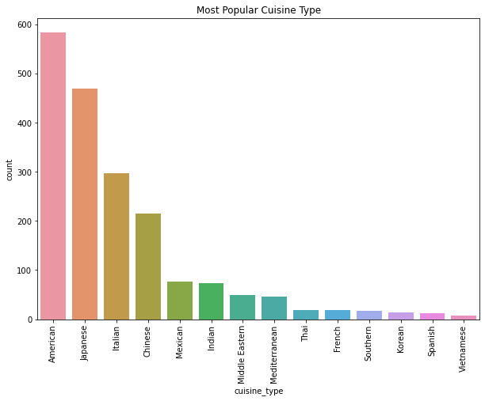

```python
plt.figure(figsize=(10,7))
plt.title('Most Popular Cuisine Type')
plt.xlabel('Cuisine Type')
sns.countplot(data=df,x='cuisine_type',  order = df['cuisine_type'].value_counts().index)
plt.xticks(rotation=90);
```

```python
df['restaurant_name'].value_counts()

# This is to see the most popular restaurants
```

```
Shake Shack                  219
The Meatball Shop            132
Blue Ribbon Sushi            119
Blue Ribbon Fried Chicken     96
Parm                          68
                            ...
Sushi Choshi                   1
Dos Caminos Soho               1
La Follia                      1
Philippe Chow                  1
'wichcraft                     1
Name: restaurant_name, Length: 178, dtype: int64
```

```python
print('The most popular day people place delivery orders')
print(df['day_of_the_week'].value_counts())
print('\n Pearcentages of orders by day type')
df['day_of_the_week'].value_counts(normalize=True)
```

```
The most popular day people place delivery orders
Weekend    1351
Weekday     547
Name: day_of_the_week, dtype: int64

 Pearcentages of orders by day type
```

```
Weekend    0.711802
Weekday    0.288198
Name: day_of_the_week, dtype: float64
```

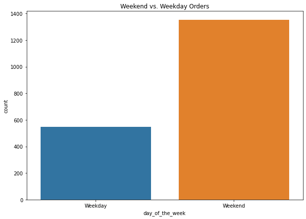

```python
plt.figure(figsize=(10,7))
plt.title('Weekend vs. Weekday Orders')
plt.xlabel('Day of the Week')
sns.countplot(data=df,x='day_of_the_week');

# Shows the results in a bar chart.
```

```python
df['customer_id'].nunique()

# This is to get the number of individual customers
```

```
1200
```

#### Observations:

The following is to get the statistics on the cost of the order being delivered.  
While the spread is wide, the majority of orders are between roughly 11 and 23 dollars.  
This points to fast casual restaurants which is backed up by "American" cuisine being the most popular.

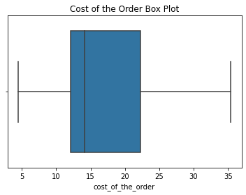

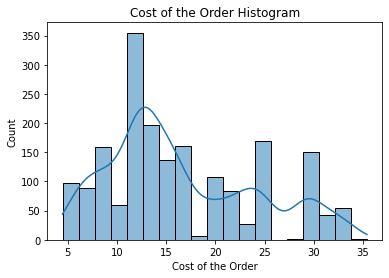

```python
plt.title('Cost of the Order Box Plot')
plt.xlabel('Cost of the Order')
sns.boxplot(data=df, x='cost_of_the_order');
plt.show()
print('\n')
plt.title('Cost of the Order Histogram')
plt.xlabel('Cost of the Order')
sns.histplot(data=df, x='cost_of_the_order', kde = True);
plt.show()
```

#### Observations:

The following is to find the length of time to prepare an order -- actually prepare and cook the food.  
The majority of the orders take between roughly 23-31 minutes with the total spread being 20-35 minutes.  
Since the average time to prepare an order in most restuarants is 10-15 minutes, this is an area for improvement.

See here for the time: https://www.quora.com/What-is-the-average-waiting-time-for-a-meal-to-be-served-after-the-customer-has-ordered-in-a-restaurant

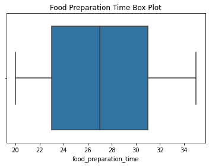

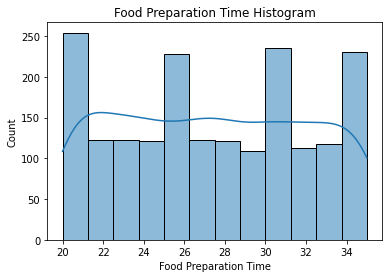

```python
plt.title('Food Preparation Time Box Plot')
plt.xlabel('Food Preparation Time')
sns.boxplot(data=df, x='food_preparation_time');
plt.show()
print('\n')
plt.title('Food Preparation Time Histogram')
plt.xlabel('Food Preparation Time')
sns.histplot(data=df, x='food_preparation_time', kde = True);
plt.show()
```

#### Observations:

The following is to find the length of time to actaully deliver the order to the customer. The majority of deliveries take between roughly 20 and 28 minutes. This is long, espically for a big city.  
This could be an area of improvement.  
Since the majority of orders come in on the weekends, it might be suggested to increase the number of drivers during the weekend and/or reduce the service area for drivers.

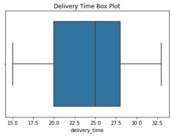

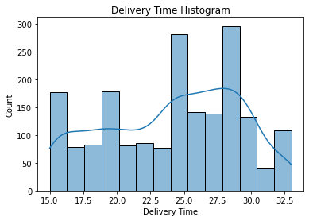

```python
plt.title('Delivery Time Box Plot')
plt.xlabel('Delivery Time')
sns.boxplot(data=df, x='delivery_time');
plt.show()
print('\n')
plt.title('Delivery Time Histogram')
plt.xlabel('Delivery Time')
sns.histplot(data=df, x='delivery_time', kde = True);
plt.show()
```

### **Question 3**: Which are the top 5 restaurants in terms of the number of orders received?

```python
tempdf=df.groupby('restaurant_name').size()
tempdf.sort_values(ascending=False).head()
```

```
restaurant_name
Shake Shack                  219
The Meatball Shop            132
Blue Ribbon Sushi            119
Blue Ribbon Fried Chicken     96
Parm                          68
dtype: int64
```

#### Observations:

Since American cuisine is the most popular cuisine type, it is not surprizing to see Shake Shack in the number 1 position. The same can be said for "Blue Ribbon Fried Chicken" in the number 4 position. Since Japanese food is the number 2 cuisine type, it is not surprizing to see "Blue Ribbon Sushi" in the number 3 spot.

In summary, these numbers backup the numbers for most popular cuisine type numbers.

### **Question 4**: Which is the most popular cuisine on weekends?

```python
tempdf = df[df['day_of_the_week'] == 'Weekend']
tempdf2 = tempdf.groupby('cuisine_type').size()
print(tempdf2.sort_values(ascending=False))
del tempdf2    #free the memory
```

```
cuisine_type
American          415
Japanese          335
Italian           207
Chinese           163
Mexican            53
Indian             49
Mediterranean      32
Middle Eastern     32
Thai               15
French             13
Korean             11
Southern           11
Spanish            11
Vietnamese          4
dtype: int64
```

#### Observations:

This is not surprizing since the top four cuisine type are the most popular overall. See question 6.

### **Question 5**: What percentage of the orders cost more than 20 dollars?

```python
tempdf=df.loc[(df['cost_of_the_order'] > 20.00) ]
x=df.shape[0]
y=tempdf.shape[0]
percent = (y/x)*100
print('The number of orders costing more than 20 dollars is:', y)
print('Percentage of the orders cost more than 20 dollars is %', round(percent, 2),sep='')
```

[output not shown]

#### Observations:

The percentage of orders more than 20 dollars is roughly 30%. This means roughly 70% of the orders are under 20 dollars pointing to fast casual restaurants and fast food restaurants. This is also born out of the fact that American cuisine is the most popular.

### **Question 6**: What is the mean order delivery time?

```python
print('Mean of order delivery time: ')
print(df['delivery_time'].mean())
round(df['delivery_time'].mean(),2)

# Added the round() fuction as it made the number easier to read
```

```
Mean of order delivery time:
24.161749209694417
```

```
24.16
```

Computing mean for food preparation time as it is needed for analysis and conclusions

```python
# Adding mean of food preparation time as it will help with question 12

print('Mean of food preparation time: ')
print(df['food_preparation_time'].mean())
round(df['food_preparation_time'].mean(),2)

# Added the round() fuction as it made the number easier to read
```

```
Mean of food preparation time:
27.371970495258168
```

```
27.37
```

#### Observations:

It takes over 24 minutes to deliver an order and over 27 minutes to prepare the order. Total start to finish time is over 51 minutes (this is also shown in Question 6). This is an area for improvement.

### **Question 7:** The company has decided to give 20% discount vouchers to the top 5 most frequent customers. Find the IDs of these customers and the number of orders they placed.

```python
tempdf = df.groupby('customer_id').size()
tempdf.sort_values(ascending=False).head()
```

```
customer_id
52832     13
47440     10
83287      9
250494     8
65009      7
dtype: int64
```

#### Observations:

20% discount for people who have only placed 9, 8, and 7 orders? That seeme aufally big. I would suggest 10%. I can see giving the discount to the top two customers.

## Introduction

- How To Improve the Food Delivery Customer Experience (Door Dash)
  - https://get.doordash.com/en-us/blog/6-strategies-to-improve-customer-experience-with-food-delivery
  - Boost customer experience in restaurants with fast delivery
  - Offer special promotions & freebies
  - Analyze customer data
- 6 Customer Experience Aspects That Any Food Delivery App Should Ensure
  - https://customerthink.com/6-customer-experience-aspects-that-any-food-delivery-app-should-ensure/
  - Real-time delivery tracking
  - Cross-Sale and Product Recommendations
  - Broad and Secure Payment Options
- Online Food Delivery: Using Data to Measure and Improve Customer Service Experience
  - https://www.driveresearch.com/market-research-company-blog/online-food-delivery-using-data-to-measure-and-improve-customer-service-experience/
  - Delivery speed
  - Reviews and recommendations
  - Waiting times
  - Evaluate the Delivery Experience
- Improving Customer Delivery Experiences (Grub Hub)
  - https://get.grubhub.com/blog/improving-customer-experience/ .
  - Make it Fast
    - 60% of delivery customers say timeliness is a key factor to their satisfaction.
  - Driver Support
    - Increase the amount of deliveries your drivers can make by finding the fastest routes, with alternates for rush hour. Or, outsource delivery to augment (or replace) your in-house drivers with an on-demand fleet.
  - Make It Accurate
  - Make it Easy
  - Make it Delicious
  - Make it Affordable
- How to Provide an Unforgettable Food Delivery Experience to Your Customers (8 Ways)
  - https://startuptalky.com/food-delivey-customer-experience/
  - Deliver Good Quality Food
  - Timely Delivery
  - Treat Every Customer as a Unique Customer
  - Surprise Discount on Food - Who Doesn’t Like It
- Food Delivery Service Statistics That You Need to Know
  - https://beambox.com/food-delivery-service-statistics
  - A study revealed that Uber Eats was the fastest to the door with an average wait time of 35 minutes and 31 seconds from the point of order (QSR Magazine)
  - Postmates came second, averaging 40 minutes and 12 seconds (QSR Magazine)
  - In the same study, Grubhub was the slowest with an average wait time of 50 minutes and 22 seconds (QSR Magazine)

I am going to analyze which restuarants take the longest to prepare and deliver the order. Improving this will help with the customer experience.

I will also determine how many customers are repeat customers for each type of restaurant (cuisine type). Repeat customers is where restaurants make their money. Restaurants should target them with special offers and promotions.

```python
# The following commands where used to create the tempdf dataframe.  They are here for documentation as I will
# read the data from the file system.
# tempdf['total_time'] = tempdf['food_preparation_time'] + tempdf['delivery_time']
# tempdf['total_time'] = tempdf['total_time'].astype(int)

tempdf = pd.read_csv('TestData_Files/foodhub_order_total_time.csv')

# It was just easier to store and read the dataframe.  Plus, I like having a backup on the file system.
```

The following section calculates the overall statistics for the complete order delivery time and plots a histogram and box chart for the total time.

```
Statistics for entire data set:
mean total time = 51.53
median total time = 52.0
standard deviation of total time = 6.83
minimum total time = 35
maximum total time = 68
```

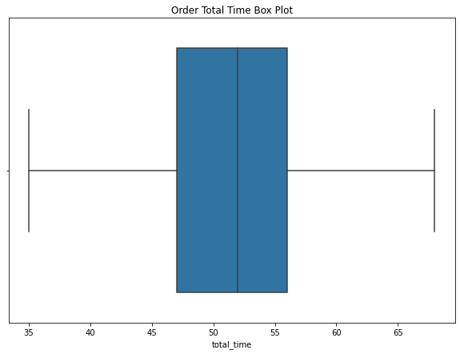

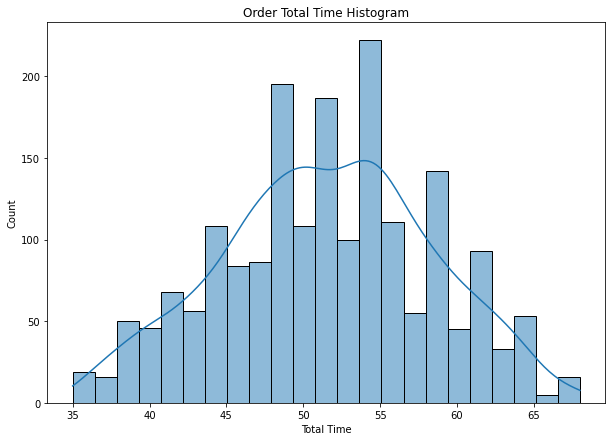

```python
# Rounding the means as it prints cleaner
print('Statistics for entire data set:')
print('mean total time =', round(tempdf['total_time'].mean(),2))
print('median total time =', round(tempdf['total_time'].median(),2))
print('standard deviation of total time =', round(tempdf['total_time'].std(),2))
print('minimum total time =', round(tempdf['total_time'].min(),2))
print('maximum total time =', round(tempdf['total_time'].max(),2))
print('\n')

plt.figure(figsize=(10,7))
plt.title('Order Total Time Box Plot')
plt.xlabel('Total Time')
sns.boxplot(data=tempdf, x='total_time');
plt.show()
print('\n')
plt.figure(figsize=(10,7))
plt.title('Order Total Time Histogram')
plt.xlabel('Total Time')
sns.histplot(data=tempdf, x='total_time', kde = True);
plt.show()
print('\n')
```

This is close to standard distribution.

The following section computes the total time to complete an order by cuisine type. This is to see if there is one or more cuisine type that is taking longer than any others. The data is computed for all days and then done for weekdays and weekends. This is to determine if and how much there is a diffence there is between the total time between weekdays and weekends. Weekends are busier than weekdays.

The results are printed and then graphed as I like to see both.

```
Orders for All Days
cuisine_type
French            52.222222
Italian           52.050336
Vietnamese        51.857143
Japanese          51.642553
American          51.633562
Southern          51.411765
Chinese           51.367442
Indian            51.191781
Mexican           51.116883
Middle Eastern    50.755102
Mediterranean     50.586957
Thai              50.473684
Spanish           50.333333
Korean            46.384615
Name: total_time, dtype: float64
```

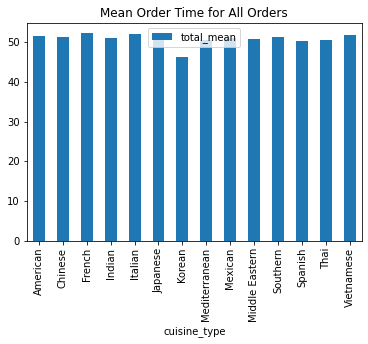

```
Weekend Orders
cuisine_type
Vietnamese        52.250000
French            51.384615
Italian           50.217391
Thai              50.133333
Japanese          50.122388
American          49.995181
Mexican           49.867925
Indian            49.836735
Chinese           49.601227
Spanish           49.363636
Southern          49.090909
Mediterranean     48.843750
Middle Eastern    48.125000
Korean            45.909091
Name: total_time, dtype: float64
```

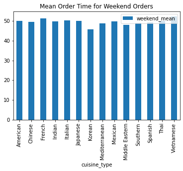

```
Weekday Orders
cuisine_type
Spanish           61.000000
Chinese           56.903846
Italian           56.219780
Middle Eastern    55.705882
Southern          55.666667
American          55.656805
Japanese          55.414815
Mediterranean     54.571429
French            54.400000
Indian            53.958333
Mexican           53.875000
Thai              51.750000
Vietnamese        51.333333
Korean            49.000000
Name: total_time, dtype: float64
```

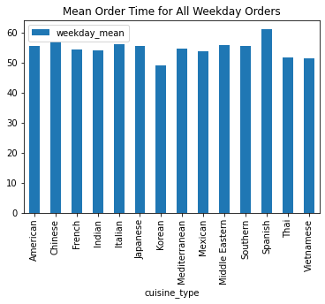

```python
print('Orders for All Days')
meandf = tempdf.groupby(['cuisine_type'])['total_time'].mean()
print(meandf.sort_values(ascending=False))
meandf = meandf.to_frame().reset_index()
meandf['total_mean'] = meandf['total_time']
meandf.drop(['total_time'], axis=1, inplace=True)
print('\n ')
meandf.plot.bar(x="cuisine_type", y="total_mean", rot=90, title='Mean Order Time for All Orders')
plt.show()
print('\n')

print('Weekend Orders')
tempdf2 = tempdf[tempdf['day_of_the_week'] == 'Weekend']
tempdf2 = tempdf2.groupby(['cuisine_type'])['total_time'].mean()
print(tempdf2.sort_values(ascending=False))
tempdf2 = tempdf2.to_frame().reset_index()
meandf['weekend_mean'] = tempdf2['total_time']
print('\n ')
meandf.plot.bar(x="cuisine_type", y="weekend_mean", rot=90, title='Mean Order Time for Weekend Orders')
plt.show()


print('Weekday Orders')
tempdf2 = tempdf[tempdf['day_of_the_week'] == 'Weekday']
tempdf2 = tempdf2.groupby(['cuisine_type'])['total_time'].mean()
print(tempdf2.sort_values(ascending=False))
tempdf2 = tempdf2.to_frame().reset_index()
meandf['weekday_mean'] = tempdf2['total_time']
del tempdf2
print('\n ')
meandf.plot.bar(x="cuisine_type", y="weekday_mean", rot=90, title='Mean Order Time for All Weekday Orders')
plt.show()
```

The next section will look at the number of orders by cuisine types for all days and then weekends and weekdays. This data will be combined with the total order time in the next section.

```
All Orders
      cuisine_type    0
0         American  584
1          Chinese  215
2           French   18
3           Indian   73
4          Italian  298
5         Japanese  470
6           Korean   13
7    Mediterranean   46
8          Mexican   77
9   Middle Eastern   49
10        Southern   17
11         Spanish   12
12            Thai   19
13      Vietnamese    7
```

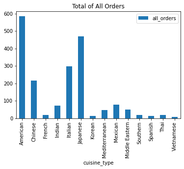

```
 Weekend Orders
      cuisine_type    0
0         American  415
1          Chinese  163
2           French   13
3           Indian   49
4          Italian  207
5         Japanese  335
6           Korean   11
7    Mediterranean   32
8          Mexican   53
9   Middle Eastern   32
10        Southern   11
11         Spanish   11
12            Thai   15
13      Vietnamese    4
```

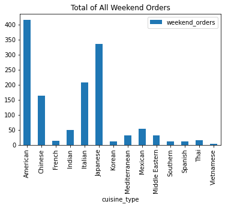

```
 Weekday Orders
      cuisine_type    0
0         American  169
1          Chinese   52
2           French    5
3           Indian   24
4          Italian   91
5         Japanese  135
6           Korean    2
7    Mediterranean   14
8          Mexican   24
9   Middle Eastern   17
10        Southern    6
11         Spanish    1
12            Thai    4
13      Vietnamese    3
```

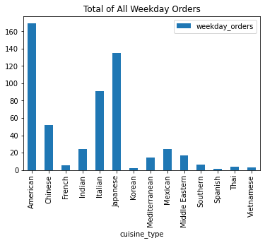

```python
print('All Orders')
tempdf2 = tempdf.groupby('cuisine_type').size()
tempdf2 = tempdf2.to_frame().reset_index()
meandf['all_orders'] = tempdf2[0]
print(tempdf2)
print('\n')
meandf.plot.bar(x="cuisine_type", y="all_orders", rot=90, title='Total of All Orders')
plt.show()

print('\n Weekend Orders')
tempdf2 = tempdf[tempdf['day_of_the_week'] == 'Weekend']
tempdf2 = tempdf2.groupby('cuisine_type').size()
tempdf2 = tempdf2.to_frame().reset_index()
meandf['weekend_orders'] = tempdf2[0]
print(tempdf2)
print('\n')
meandf.plot.bar(x="cuisine_type", y="weekend_orders", rot=90, title = 'Total of All Weekend Orders')
plt.show()

print('\n Weekday Orders')
tempdf2 = tempdf[tempdf['day_of_the_week'] == 'Weekday']
tempdf2 = tempdf2.groupby('cuisine_type').size()
tempdf2 = tempdf2.to_frame().reset_index()
meandf['weekday_orders'] = tempdf2[0]
print(tempdf2)
print('\n')
meandf.plot.bar(x="cuisine_type", y="weekday_orders", rot=90, title = 'Total of All Weekday Orders')
plt.show()
```

This is to determine if there is any correlation between the total order time and the number of orders. Do more orders mean a longer total order time? The rational answer is yes, but hard facts are better.

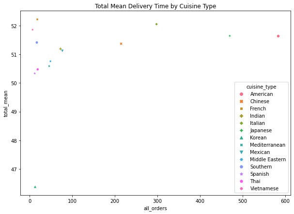

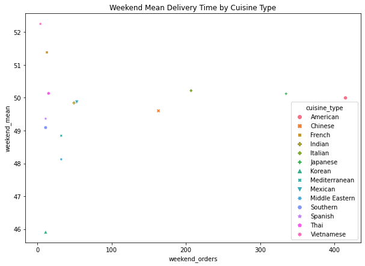

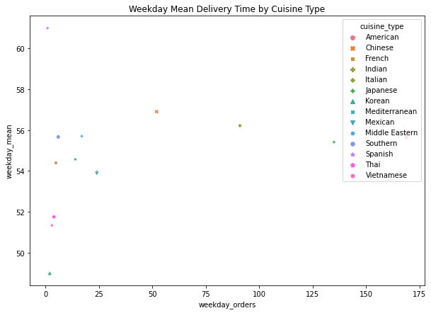

```python
plt.figure(figsize=(10,7))
plt.title('Total Mean Delivery Time by Cuisine Type')
sns.scatterplot(data=meandf, y='total_mean', x='all_orders', hue='cuisine_type', style='cuisine_type');
plt.show()

print('\n')
plt.figure(figsize=(10,7))
plt.title('Weekend Mean Delivery Time by Cuisine Type')
sns.scatterplot(data=meandf, y='weekend_mean', x='weekend_orders', hue='cuisine_type', style='cuisine_type');
plt.show()

print('\n')
plt.figure(figsize=(10,7))
plt.title('Weekday Mean Delivery Time by Cuisine Type')
sns.scatterplot(data=meandf, y='weekday_mean', x='weekday_orders', hue='cuisine_type', style='cuisine_type');
plt.show()
```

For the big four cuisine types:

- American
- Japanese
- Italian
- Chinese

More orders does not mean a longer total order time. The order time depends on the cuisine type. There is a difference between the weekend and weekday mean times, but it is not that large.

This section looks at the correlation between the number of orders and the total delivery time across all days, weekends, and weekdays. This is to determine the correlation at what I call grand scale or big picture. The last section broke it down by cuisine types. This section looks at the data for all restuarants.

```
Correlation Between All Orders and Mean Delivery Time
```

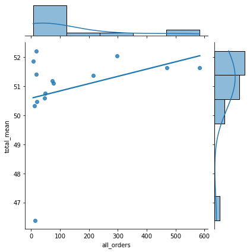

```
Correlation Between Weekend Orders and Mean Delivery Time
```

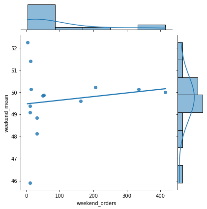

```
Correlation Between Weekday Orders and Mean Delivery Time
```

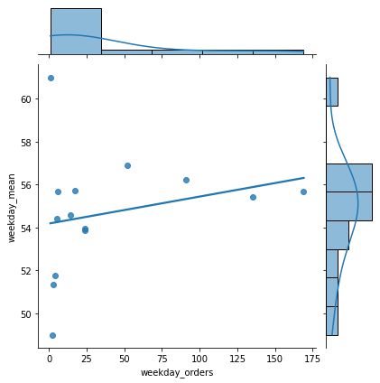

```python
print('Correlation Between All Orders and Mean Delivery Time')
sns.jointplot(data=meandf, x='all_orders', y='total_mean', ci=False, kind="reg");
plt.show()
print('\n')
print('Correlation Between Weekend Orders and Mean Delivery Time')
sns.jointplot(data=meandf, x='weekend_orders', y='weekend_mean', ci=False, kind="reg");
plt.show()
print('\n')
print('Correlation Between Weekday Orders and Mean Delivery Time')
sns.jointplot(data=meandf, x='weekday_orders', y='weekday_mean', ci=False, kind="reg");
plt.show()
```

There is a positive correlation between the number of orders and the total time to deliver an order. This is the case across all days, weekends, and weekdays. While the nuumber of orders is different between weekends and weekdays, the correlation is positive for both. Logically one would think this, but now there are numbers to reinforce the belief.

The following section computes how many repeat customer there are for each restaurant and the sum of there orders. This is to compute the percentage of sales for one off customers as opposed to repeat customers. The percentage is computed in a following section.

This is based on the addage that it is cheaper to keep a customer rather than get a new customers. Repeat business is also the life blood for any restaurant.

A create a DataFrame, order it by restaurant name and customer id, and then iterate over it to get the sum for the repeat customers. One off customers are marked as zero sum of orders and the dropped at the end of the code section. This was the easiest way to do it and used the native drop_duplicates function.

```python
# create a dataframe to hold the summarized data
custdf = {'customer_id' : [13], 'restaurant_name' : ['joes'], 'num_repeat' : [0], 'sum_order_cost' : [0], 'food_type' : ['Burgers'] }
custdf = pd.DataFrame(data=custdf)

# copy of the master dataframe and sort by customer id
sortdf = df.copy()
sortdf.sort_values(['restaurant_name' , 'customer_id'], inplace=True, ascending=True)
sortdf.reset_index(drop=True, inplace=True)

#  I am old fashined.  I like initializing variables before they are used.
newcust = 0
oldcust = 0
numrepeat = 0
sumorder = 0
rownum = 1
lastrow = 0

# iterate over the sortdf.  if the n customer_id equals the n-1 customer_id, then add the n cost_of_order to the
# running order total.  if this is a first repetition (numrepeat == 0), the add the n-1 cost_of_the_order to the
# running order total.  if a customer has ordered more than 2 times from a restaurant, then the dataframe will have
# an entry for the second and all subsequent orders.  this is handled in the next section.
for index, row in sortdf.iterrows():
    newcust = row['customer_id']
    if newcust == oldcust:
        if numrepeat == 0:
            numrepeat = 1
            sumorder = oldorder
        sumorder = sumorder + row['cost_of_the_order']
        numrepeat += 1
    if numrepeat != 0 and newcust == oldcust:
        to_append = [row['customer_id'], row['restaurant_name'], numrepeat, sumorder, row['cuisine_type']]
        custdf_length = len(custdf)
        custdf.loc[custdf_length] = to_append
    if newcust != oldcust:
        numrepeat = 0
        sumorder = 0
    oldcust = newcust
    oldorder = row['cost_of_the_order']

# using the drop.duplicates function to only keep the last order a customer placed if there were more than 2 orders.
custdf.drop(0, axis=0, inplace=True)    #drop the first row that was used to initialize the series
custdf.drop_duplicates(subset=['customer_id', 'restaurant_name'], keep='last', inplace=True)
custdf.reset_index(drop=True, inplace=True)

print(custdf.head(10))
del sortdf     #free the memory.
```

```
   customer_id        restaurant_name  num_repeat  sum_order_cost food_type
0       286386        5 Napkin Burger           2           36.96  American
1        95164                   Amma           3           45.26    Indian
2       292343             Amy Ruth's           2           28.34  Southern
3       184325            Asuka Sushi           3           65.00  Japanese
4        92096                 Aurora           2           28.67   Italian
5        62667  Balthazar Boulangerie           2           51.03    French
6       229946  Balthazar Boulangerie           3           58.16    French
7        47440             Bareburger           6          102.15  American
8        59749             Bareburger           2           35.84  American
9       120833             Bareburger           2           49.18  American
```

```python
# Utility section for saving and loading the repeat customer data.
# I also like having a backup on the file system.

#custdf.to_csv('TestData_Files/foodhub_repeat_customers.csv',index=False)
custdf = pd.read_csv('TestData_Files/foodhub_repeat_customers.csv')
```

This is the analysis section to determine which restaurant and cuisine types have the most repeat customer and sum of their orders. The first section does the computation and graphing for cuisine type and sum of orders.

```
                num_repeat  sum_order_cost
food_type
Japanese               250         3973.80
American               240         4070.52
Italian                109         1802.28
Chinese                 90         1453.32
Indian                  31          573.61
Mexican                 25          438.61
Middle Eastern          21          404.86
Mediterranean           17          267.28
French                   9          186.07
Southern                 9          152.75
Spanish                  7          138.83
Thai                     6          112.83
Korean                   4           59.04
Vietnamese               4           56.37

 Correlation Between Total Cost of Orders and Number of Repeated Orders
```

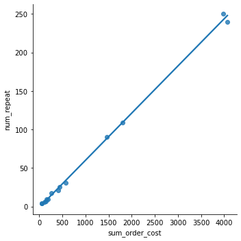

```python
# get the sum of the repeated orders for each cuisine type and display as a frame and a lmplot.

orderdf = custdf.groupby(['food_type'])['num_repeat', 'sum_order_cost'].sum()
print(orderdf.sort_values(by='num_repeat',ascending=False))
print('\n Correlation Between Total Cost of Orders and Number of Repeated Orders')
sns.lmplot(data=orderdf, x='sum_order_cost', y='num_repeat',ci=False);
plt.show()
```

More repeat customers, more sales. Not surprizing.

This section does the computation and graphing for customer id and sum of orders. Which customers repeated the most?

```
Order and print the customers with the most orders for all cuisine types
             num_repeat  sum_order_cost
customer_id
47440                10          158.18
52832                 9          157.59
83287                 8          124.81
60052                 6          102.24
82041                 6           99.09
...                 ...             ...
114919                2           37.93
115519                2           32.46
118776                2           21.83
118975                2           17.95
399520                2           22.03

[328 rows x 2 columns]


Order and print to get the number of times any customer placed a repeat order.
num_repeat
2     243
3      41
4      26
5       8
6       7
8       1
9       1
10      1
dtype: int64
```

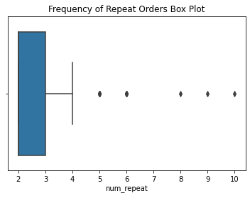

```python
# order and print the customers with the most orders for all cuisine types

print('Order and print the customers with the most orders for all cuisine types ')
orderdf = custdf.groupby(['customer_id'])['num_repeat', 'sum_order_cost'].sum()
print(orderdf.sort_values(by='num_repeat',ascending=False))
print('\n')

# Order and print to get the number of times any customer placed a repeat order.

print('Order and print to get the number of times any customer placed a repeat order.')
print(orderdf.groupby('num_repeat').size())
print('\n')
plt.title('Frequency of Repeat Orders Box Plot')
sns.boxplot(data=orderdf, x='num_repeat');
plt.show()
```

The box plot shows not many repeat customers overall. 2 to 3 repeat customers per restaurant with the top being 4. There are some outliiers. Heavily right skewed.

This is something to flag. If repeat customers are the life blood of a restaurant, why are there so few repeating customers?

This section does the computation and graphing for the overall number of repeats. These numbers match what was seen in the last section. The first section of code shows the number of instances for each repeat level. The section shows the individual restaurants for each repeat level.

As with the last section, there is very little repeat business. This is a flag.

```
num_repeat
2    568
3    156
4     76
5     10
6     12
Name: num_repeat, dtype: int64
```

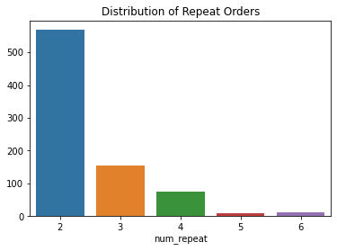

```python
# Do a bar plot to get an overall view of the number and distribution of repeats

orderdf = custdf.groupby(['num_repeat'])['num_repeat'].sum()
print(orderdf, '\n')
plt.title('Distribution of Repeat Orders')
plt.xlabel('Number of Repeat Orders')
sns.barplot(orderdf.index, orderdf.values)
plt.show()
print('\n \n')
```

```
num_repeat  sum_order_cost  restaurant_name
2           12.61           RedFarm Broadway     12.61
            13.15           Sushi of Gari 46     13.15
            13.40           J. G. Melon          13.40
            14.21           Dos Caminos          14.21
            15.09           Osteria Morini       15.09
            15.13           Sarabeth's East      15.13
            15.38           The Meatball Shop    15.38
            15.43           Five Leaves          15.43
            15.57           J. G. Melon          15.57
            16.15           Shake Shack          16.15
Name: sum_order_cost, dtype: float64

num_repeat  sum_order_cost  restaurant_name
4           76.11           Blue Ribbon Sushi                 76.11
            78.29           Lantern Thai Kitchen              78.29
            83.53           Shake Shack                       83.53
            88.66           Han Dynasty                       88.66
            89.33           Benihana                          89.33
            91.04           Blue Ribbon Fried Chicken         91.04
5           69.89           The Meatball Shop                 69.89
            94.38           Shake Shack                       94.38
6           102.15          Bareburger                       102.15
            122.03          Blue Ribbon Sushi Bar & Grill    122.03
Name: sum_order_cost, dtype: float64
```

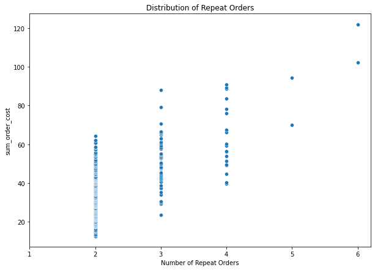

```python
# Find the restaurant with the most repeat customers and sum of all the repeated orders
# Plot the data on a scatter plot
orderdf = custdf.groupby(['num_repeat', 'sum_order_cost', 'restaurant_name'])['sum_order_cost'].sum()
orderdf.sort_values(ascending=False)
print(orderdf.head(10), '\n')
print(orderdf.tail(10), '\n')
plt.figure(figsize=(10,7))
plt.title('Distribution of Repeat Orders')
plt.xlabel('Number of Repeat Orders')
sns.scatterplot(data=orderdf, x='num_repeat', y='sum_order_cost')
plt.xticks([1,2,3,4,5,6],['1','2','3','4','5','6'])
plt.show()
```

Many repeats at the 2 and 3 level. Fewer for 4, 5, and 6.

This section computes the percentage of repeat orders as compared to total orders for each restaurant. How much did the a restaurant make from the repeat orders. I am show the top 20 as the bottom 20 will all be zero since they did not have any repeats.

```python
# Create 2 dataframes containing the restaurant namme and sum of the order cost of the repeated orders (custdf)
# and another datafram containing the restaurant name and sum of all the orders for all restaurants
# merge the dataframes by rows
# replace all nan with zero as nan would indicate zero repeated orders
# compute percentage of repeated orders to all orders and load into new column

repeatdf = custdf.groupby(['restaurant_name'])['sum_order_cost'].sum()
alldf = df.groupby(['restaurant_name'])['cost_of_the_order'].sum()
profitdf = pd.concat([alldf , repeatdf], axis=1)
profitdf['sum_order_cost'] = profitdf['sum_order_cost'].replace(np.nan, 0)
profitdf['repeat_perc'] = 0.0
profitdf.reset_index(inplace=True)
profitdf['repeat_perc'] = (profitdf['sum_order_cost'] / profitdf['cost_of_the_order']) *100
profitdf.sort_values(by='repeat_perc', ascending=False).head(20)
```

|  | restaurant_name | cost_of_the_order | sum_order_cost | repeat_perc |
| --- | --- | --- | --- | --- |
| 99 | Mission Cantina | 87.45 | 87.45 | 100.000000 |
| 147 | Tarallucci e Vino Restaurant | 40.69 | 40.69 | 100.000000 |
| 9 | Aurora | 28.67 | 28.67 | 100.000000 |
| 15 | Bhatti Indian Grill | 62.23 | 62.23 | 100.000000 |
| 26 | Bukhara Grill | 23.72 | 23.72 | 100.000000 |
| 57 | Five Leaves | 37.80 | 37.80 | 100.000000 |
| 28 | Byblos Restaurant | 49.47 | 49.47 | 100.000000 |
| 74 | Hot Kitchen | 42.54 | 42.54 | 100.000000 |
| 8 | Asuka Sushi | 65.00 | 65.00 | 100.000000 |
| 169 | Xe May Sandwich Shop | 22.03 | 22.03 | 100.000000 |
| 52 | DuMont Burger | 65.86 | 65.86 | 100.000000 |
| 82 | Junoon | 115.25 | 115.25 | 100.000000 |
| 43 | DespaÌ±a | 33.04 | 33.04 | 100.000000 |
| 70 | Haveli Indian Restaurant | 34.82 | 34.82 | 100.000000 |
| 91 | Le Grainne Cafe | 45.21 | 45.21 | 100.000000 |
| 90 | Lantern Thai Kitchen | 78.29 | 78.29 | 100.000000 |
| 105 | Olive Garden | 22.84 | 22.84 | 100.000000 |
| 156 | Tony's Di Napoli | 76.10 | 64.80 | 85.151117 |
| 14 | Benihana | 105.44 | 89.33 | 84.721168 |
| 104 | Olea | 43.12 | 36.43 | 84.485158 |

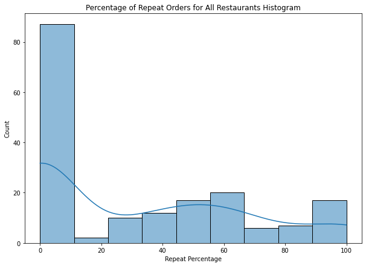

```python
# Histogram to get a sense of the repeat distribution percentage

plt.figure(figsize=(10,7))
plt.title('Percentage of Repeat Orders for All Restaurants Histogram')
plt.xlabel('Repeat Percentage')
sns.histplot(data=profitdf, x='repeat_perc', kde=True)
plt.show()
```

### **Question 8:** The company wants to provide a promotional offer in the advertisement of the restaurants. The condition to get the offer is that the restaurants must have a rating count of more than 50 and the average rating should be greater than 4. Find the restaurants fulfilling the criteria to get the promotional offer.

```python
# With thanks to Tasleem for the Best Practice to copy the data before changing it.
# A way too practical piece of advice.

# Replace all "Not given" with NaN since a "Not Givern" means no ratings.
# Since the assignment is to find restaurants with an average rating of greater than 4, a subsituation
# of "Not given" for NaN will not change the overall results.

tempdf = df.copy()
tempdf['rating'] = tempdf['rating'].replace(['Not given'],np.nan)
tempdf['rating'] = tempdf['rating'].astype(float)
tempdf2 = tempdf.groupby(['restaurant_name'])['rating'].mean()
tempdf2 = tempdf2.reset_index()
tempdf2 = tempdf2.loc[(tempdf2['rating'] > 4.0) ]
tempdf2 = tempdf2.reset_index()
print('There are ', tempdf2.shape[0], ' restaurants with a rating greater than 4  \n', sep='')
print('Here are the first 10 restaurants')
print(tempdf2.head(10))
del tempdf2   # Free the memory.
```

```
There are 110 restaurants with a rating greater than 4

Here are the first 10 restaurants
   index        restaurant_name    rating
0      0             'wichcraft  5.000000
1      1              12 Chairs  4.500000
2      3              67 Burger  5.000000
3      5                   Amma  4.500000
4      7     Anjappar Chettinad  5.000000
5      8            Asuka Sushi  5.000000
6     10                 Balade  5.000000
7     11  Balthazar Boulangerie  4.200000
8     12              Barbounia  4.500000
9     13             Bareburger  4.058824
```

### **Question 9:** The company charges the restaurant 25% on the orders having cost greater than 20 dollars and 15% on the orders having cost greater than 5 dollars. Find the net revenue generated by the company across all orders.

```python
tempdf=df.loc[(df['cost_of_the_order'] > 20.00) ]
largecost=tempdf['cost_of_the_order'].sum()
print('The gross revenue for orders greater than $20.00 is $', largecost, sep='')
largemargin=round(largecost*0.25,2)
print('The net revenue for orders greater than $20.00 is $', largemargin,'\n', sep='')

tempdf=df.loc[(df['cost_of_the_order'] <= 20.00) & (df['cost_of_the_order'] > 5.00) ]
smallcost=tempdf['cost_of_the_order'].sum()
smallcost=round(smallcost,2)
smallmargin=round(smallcost*0.25,2)
print('The gross revenue for orders greater than $5.00 and less than and equal to $20.00 is $', smallcost, sep='')
print('The net revenue for orders greater than $5.00 and less than and equal to $20.00 is $', smallmargin, '\n', sep='')
print('The net revenue for all orders is $', smallmargin+largemargin, '\n', sep='')
del tempdf   # Free the memory
```

```
The gross revenue for orders greater than $20.00 is $14754.91
The net revenue for orders greater than $20.00 is $3688.73

The gross revenue for orders greater than $5.00 and less than and equal to $20.00 is $16517.17
The net revenue for orders greater than $5.00 and less than and equal to $20.00 is $4129.29

The net revenue for all orders is $7818.02
```

#### Observations:

Using loc() function with conditionals to determine the gross revenue and net revenue for the orders.

### **Question 10:** The company wants to analyze the total time required to deliver the food. What percentage of orders take more than 60 minutes to get delivered from the time the order is placed?

Note: I did the compuation for 60 minutes and then 40 and 35 minutes since I wanted to use the data for Question 12 and for the final recommendations.

```python
# The answer assumes "Total delivery time" means time to prepare the order plus the time to deliver it.
# Basically the time from when I hang up the phone (or hit enter when ordering on line) to the time the
# door bell rings.

tempdf = pd.read_csv('TestData_Files/foodhub_order_total_time.csv')    # get a clean copy of the data
tempdf2=tempdf.loc[(tempdf['total_time'] > 60) ]
x=tempdf2.shape[0]
y=tempdf.shape[0]
del tempdf2
print('The total number of orders is:',  y )
print('The total number of orders taking longer than 60 minutes to be delivered is:', x )
print('The percentage of orders taking longer than 60 minutes to be delivered is: ', round((x/y)*100,2), '%', sep='' )
```

```
The total number of orders is: 1898
The total number of orders taking longer than 60 minutes to be delivered is: 200
The percentage of orders taking longer than 60 minutes to be delivered is: 10.54%
```

```python
# Doing an additional analysis to determine number of restaurants that take longer than 40 minutes to prepare
# and deliver a food order.

tempdf = pd.read_csv('TestData_Files/foodhub_order_total_time.csv')    # get a clean copy of the data
tempdf2=tempdf.loc[(tempdf['total_time'] > 40) ]
x=tempdf2.shape[0]
y=tempdf.shape[0]
del tempdf2
print('The total number of orders is:',  y )
print('The total number of orders taking longer than 40 minutes to be delivered is:', x )
print('The percentage of orders taking longer than 40 minutes to be delivered is: ', round((x/y)*100,2), '%', sep='' )
```

```
The total number of orders is: 1898
The total number of orders taking longer than 40 minutes to be delivered is: 1767
The percentage of orders taking longer than 40 minutes to be delivered is: 93.1%
```

```python
# Doing an additional analysis to determine number of restaurants that take longer than 35 minutes to prepare
# and deliver a food order.

tempdf = pd.read_csv('TestData_Files/foodhub_order_total_time.csv')    # get a clean copy of the data
tempdf2=tempdf.loc[(tempdf['total_time'] > 35) ]
x=tempdf2.shape[0]
y=tempdf.shape[0]
del tempdf2
print('The total number of orders is:',  y )
print('The total number of orders taking longer than 35 minutes to be delivered is:', x )
print('The percentage of orders taking longer than 35 minutes to be delivered is: ', round((x/y)*100,2), '%', sep='' )
```

```
The total number of orders is: 1898
The total number of orders taking longer than 35 minutes to be delivered is: 1895
The percentage of orders taking longer than 35 minutes to be delivered is: 99.84%
```

### **Question 11:** The company wants to analyze the delivery time of the orders on weekdays and weekends. How does the mean delivery time vary during weekdays and weekends?

```python
# Compute the weekend delivery time first and then the weekday delivery time and display results
# Round results to integers for display and fractions of minutes do not matter in this case

tempdf = df[df['day_of_the_week'] == 'Weekend']
x=tempdf['delivery_time'].mean()
#print('The mean weekend delivery time is:', round(x,2), 'minutes')
print('The mean weekend delivery time is:', round(x), 'minutes')

tempdf = df[df['day_of_the_week'] == 'Weekday']
y=tempdf['delivery_time'].mean()
#print('The mean weekend delivery time is:', round(y,2), 'minutes')
print('The mean weekend delivery time is:', round(y), 'minutes')
#print('The difference between the weekday and weekend delivery times is', round(y-x,2), 'minutes')
print('The difference between the weekday and weekend delivery times is', round(y-x), 'minutes')
```

```
The mean weekend delivery time is: 22 minutes
The mean weekend delivery time is: 28 minutes
The difference between the weekday and weekend delivery times is 6 minutes
```

#### Observations:

I decided to use the round() function on the results as the original results with round(x,2) had a result of 22.47 for the weekend delivery time and 28.34 for the weekend delivery time. The oringal difference was 5.87 which really does not mean much. Rounding the means and the difference to a whole number just made more sense. Besides, what is 5.87 minutes anyway?

At 6 minutes, there is not much differece between the weekend and weekday delivery times.

### Recommendations:

- Work on getting the time to prepare and deliver an order to between 35 and 40 minutes
  - 30 minutes is the national standard
  - It should take 10 to 15 minutes to prepare an order
  - It should not take over 15 minutes to deliver an order
- Start by working on the top four cusinie types getting the most orders:
  - American
  - Japanese
  - Italian
  - Chinese
- Add drivers on weekends when demand is the highest
- Consider restricting delivery area to speed the delivery time time
- Work with the restaurant partners to improve food preparation time
- Consider dropping the cuisine types with the least orders:
  - Southern 17 orders
  - Korean 13 orders
  - Spanish 12 orders
  - Vietnamese 7 orders
- Work on increasing the number of repeat customers
  - Add incentives or giving discounts on future orders

### Future considerations:

- Add weather data to the analysis to determine if/how weather is affecting delivery times
- Add time of day to the orders to detemine when the majority of orders are placed on the weekends
  - That is when drivers will be needed the most
- Add geographic data to determine what areas of the city generate the most orders
  - Preposition drivers in those areas to be ready for the orders
- Perform a deeper drive on the top four cuisine types to determine exact cost and profit for the deliveries
- Perform sentament analysis on customer rating and reviews